# Perception réciproque entre cyclistes et automobilistes

## c- Connaissances du code de la route

Les conflits entre usagers peuvent être fréquents et causés par une ignorance du code de la route et donc une mauvaise anticipation du comportement de l’autre. Nous nous intéressons à deux aspects du code notamment les panneaux tourne-à-droite et les SAS vélo.

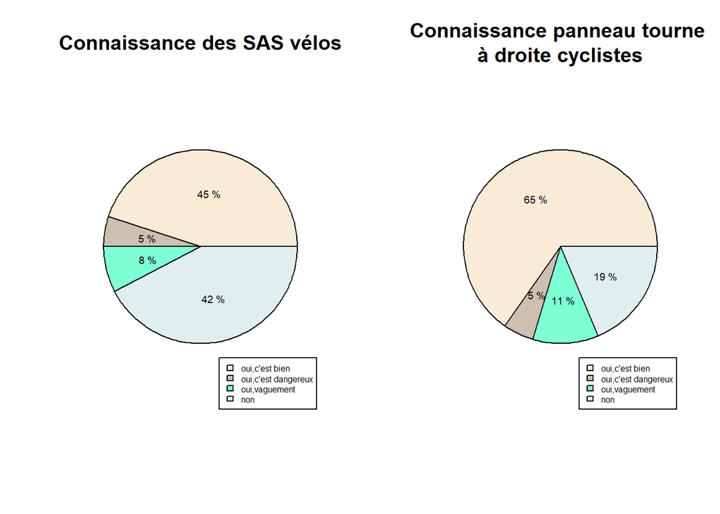

Nous allons tester l’hypothèse selon laquelle la probabilité qu’un cycliste ait un conflit avec un automobiliste dépend fortement de sa connaissance des ces dispositifs. En effet, des réponses au questionnaire qualitatif, ressortait que les causes de conflit les plus citées sont, entre autre:

- quand les cyclistes se placent dans les SAS vélo devant les automobilistes au feu rouge;
- quand le cycliste ne s’arrête pas au feu rouge alors que, dans certains cas, le panneau tourne-à-droite cycliste l’y autorise.

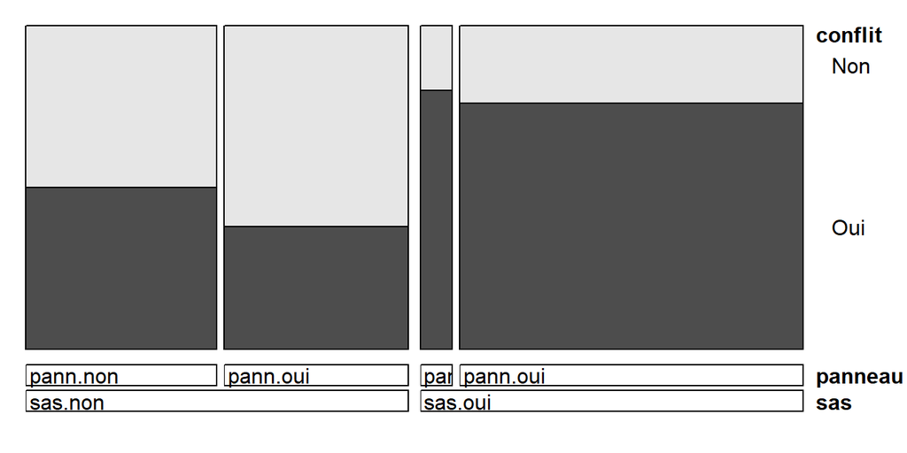

Par ailleurs, les automobilistes sont les usagers avec lesquels les cyclistes ont le plus de conflit suivi des piétons et des véhicules utilitaires.

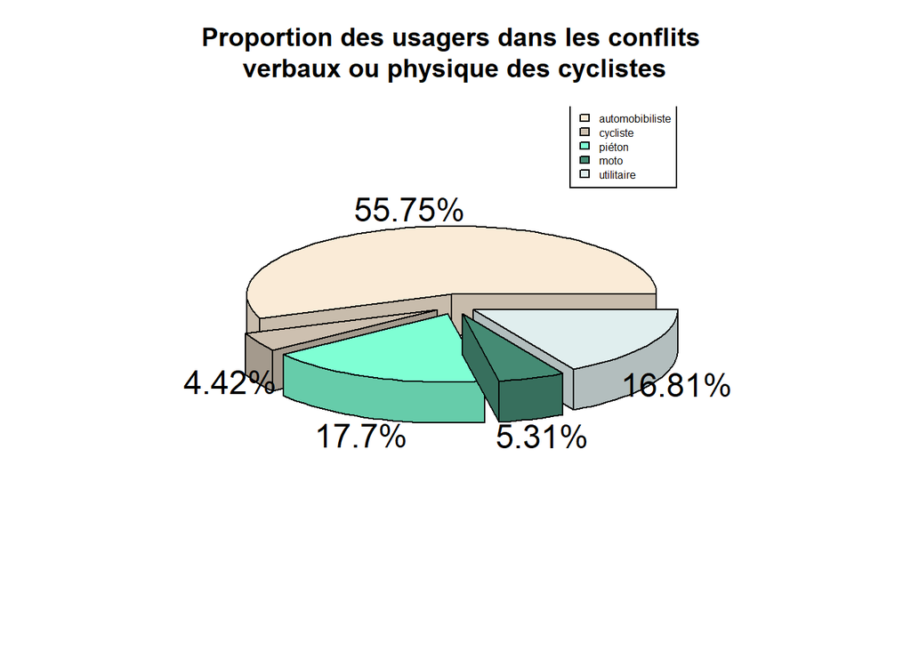

Les causes de ces conflits se répartissent comme suit:

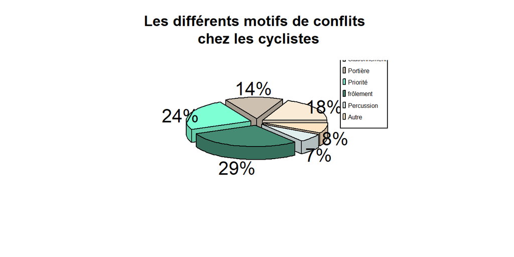

## d- Analyse des commentaires des cyclistes

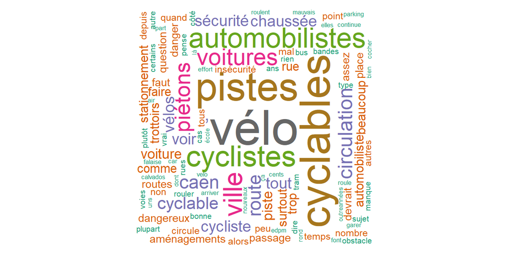

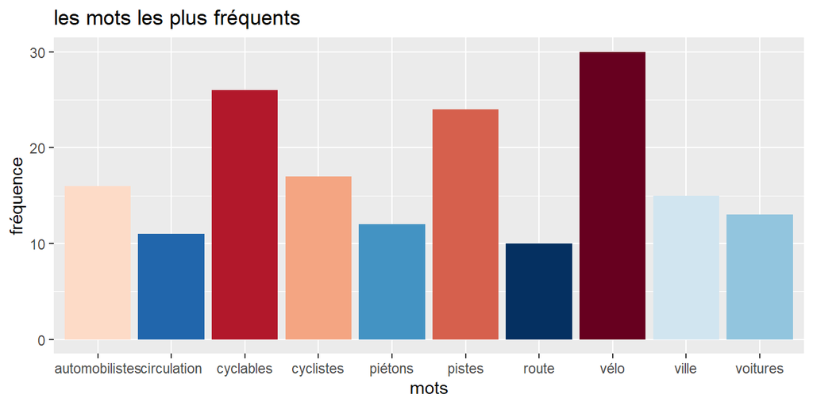

La figure ci-dessus indique que les commentaires des cyclistes s’articulent autour de trois aspects que sont:

- la pratique du vélo;
- les aménagements cyclables
- la circulation en ville à vélo.

Les commentaires liés à la pratique du vélo mettent en avant les points suivants:

- l’absence de sensibilisation à l’égard de la pratique du vélo et les dangers qui y sont liés;
- la vulnérabilité des cyclistes face aux automobilistes.

```r
"[2] a mon avis, les automobilistes ne comprennent pas ce qu'implique de circuler
à vélo (effort, exposition aux dangers, sentiment d'insécurité, inhalation des gaz
d'échappement, etc.). une sensibilisation à leur égard serait bienvenue."

"[4] sur les routes de campagne le vélo est dangereux, les automobilistes roulent
vite cat il n'y a pas de radar...le  gros danger c'est l'automobiliste qui voyant
une voiture arriver en face double coûte que coûte en frôlant le cycliste plutôt
que de patienter."

"[15] de façon général un cycliste est toujours  vulnérable qu'un automobiliste.
il est dommage qu'il n'y ait que peu ou pas de sensibilisation au vélo lors du
passage du permis de conduire."
```

Pour ce qui est des aménagements cyclables, il a été mis en avant:

- la discontinuité de nombreuses pistes cyclables;
- la question de l’entretien de ces aménagements;
- le problème des véhicules se stationnant sur ces aménagements.

Enfin, pour ce qui est de la circulation en ville, les cyclistes se préoccupent plutôt des aspects suivants:

- les conflits avec les piétons;
- la pollution des voitures (sonore ou à gaz à effets de serre)

Outre la compréhension de la perception des cyclistes, il importe d’étudier la perception des automobilistes dans une optique d’améliorer le vivre ensemble entre ces usagers et encourager l’usage du vélo.

# III- Analyse de la Perception des automobilistes

La perception des automobilistes est analysée selon trois aspects:

- Leur satisfaction en termes de partage de la chaussée avec les cyclistes,
- Leur perception de certains comportements des cyclistes,
- leur connaissance de certains aspects du code de la route touchant au vélo.

## a- Partage de la chaussée avec les cyclistes

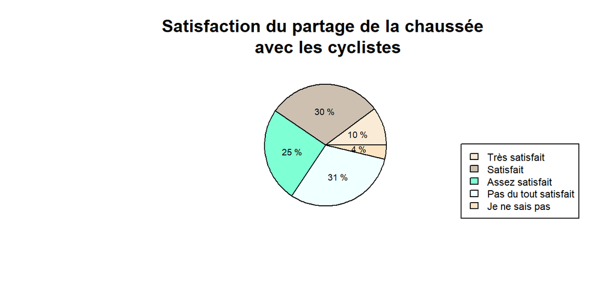

Moins de la moitié des automobilistes se dit satisfaite du partage de la chaussée avec les cyclistes, soit 41% sont “très satisfaits” ou “satisfaits”.

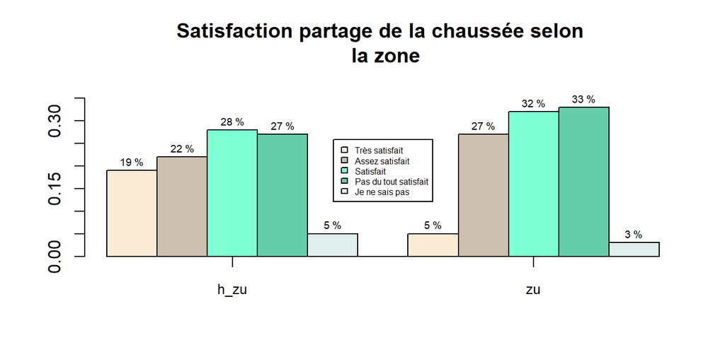

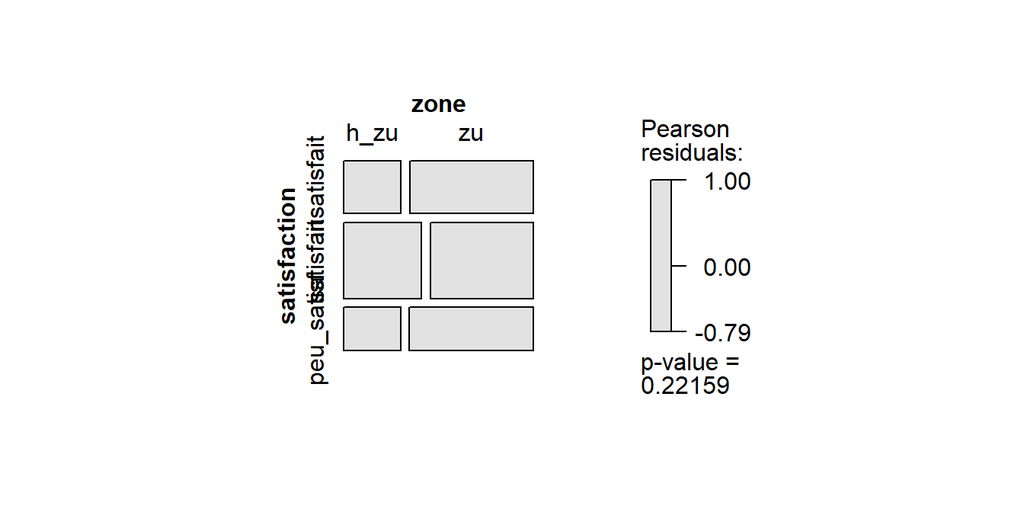

L’insatisfaction ou la satisfaction des automobilistes peut être expliquée par différents facteurs: certains comportements dangereux des cycliste notamment l’absence de signalisation ou le non respect des feux rouges ou le relentissement dans la circulation.

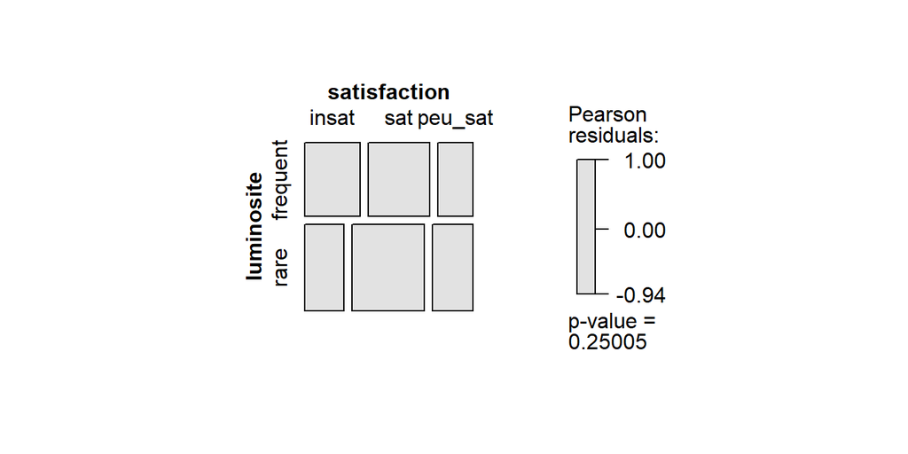

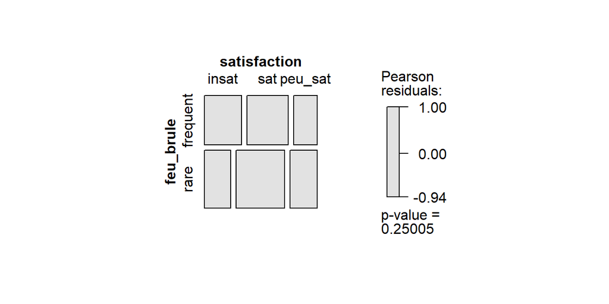

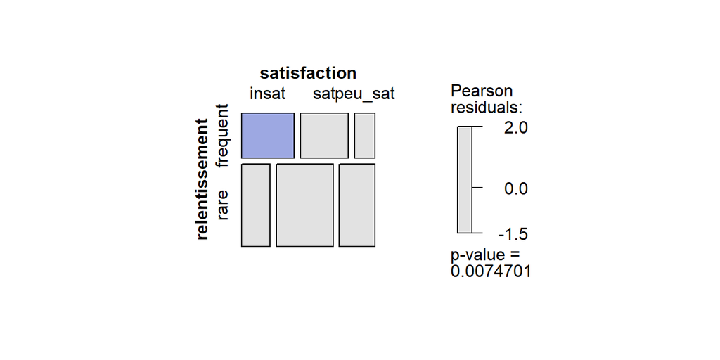

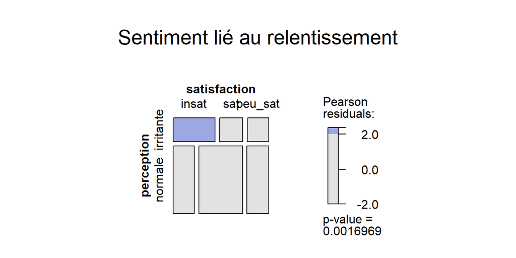

Aussi les facteurs cités précedemment, notamment l’absence d’éclairage des cyclistes et le non respect des feux rouges par ces derniers ne sont associés à la satisfaction ou insatisfaction des automobilistes dans leur partage de la chaussée avec les cyclistes.

Par contre, l’irritation suscitée par un cycliste qui les relentit dans la circulation est significativement corrélée à leur insatisfaction.

L’insatisfaction des automobilistes peut être aussi expliquée par certains comportements jugés irrespectueux des cyclistes jugés .

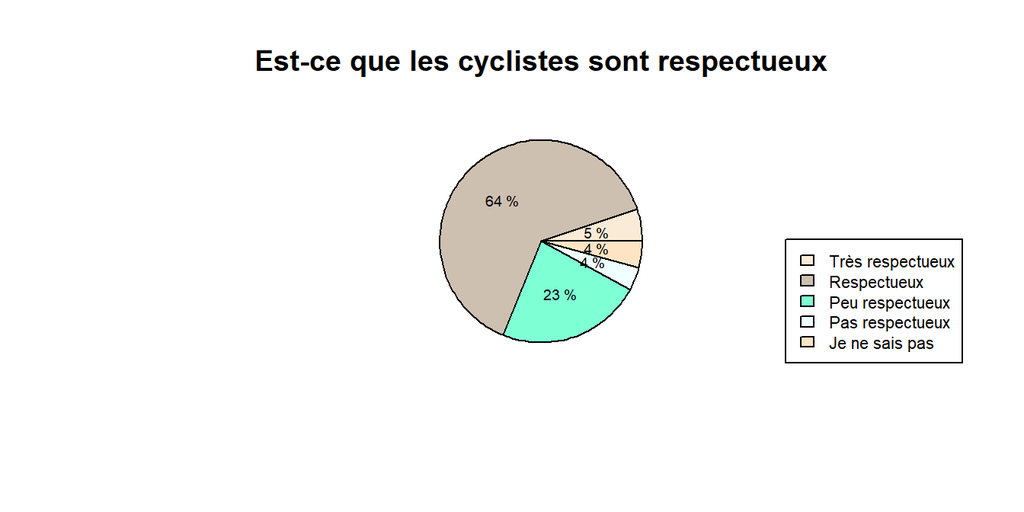

Une grande partie des automobilistes pensent que les cyclistes sont respectuex dans la circulation, soit 68%. L’étude du comportement respectueux ou irrespectueux d’un usager importe dans la mesure ces comportements peuvent suciter des conflits et de la colère pouvant conduire à des accidents ou la mise en danger des usagers protagonistes.

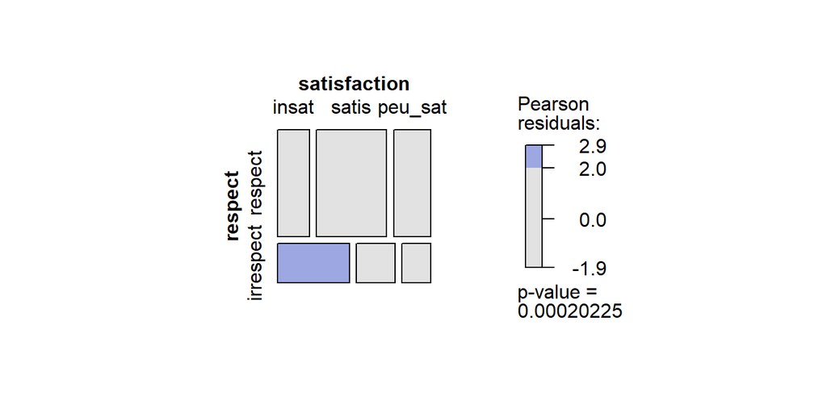

Nous pouvons constater que le manque de respect provoque significativement une insatisfaction chez les automobilistes. Ainsi, quels en sont les déterminants?

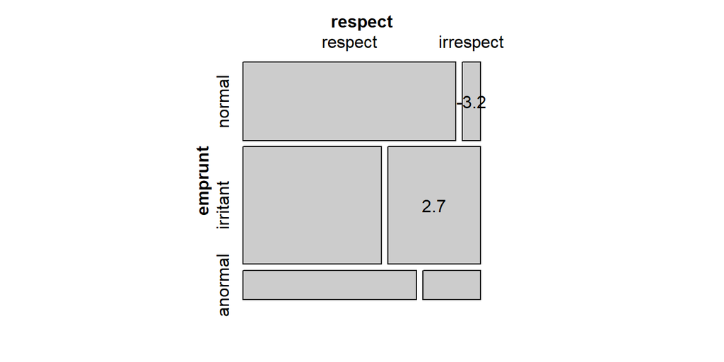

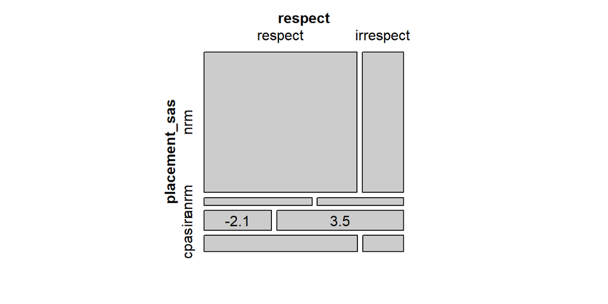

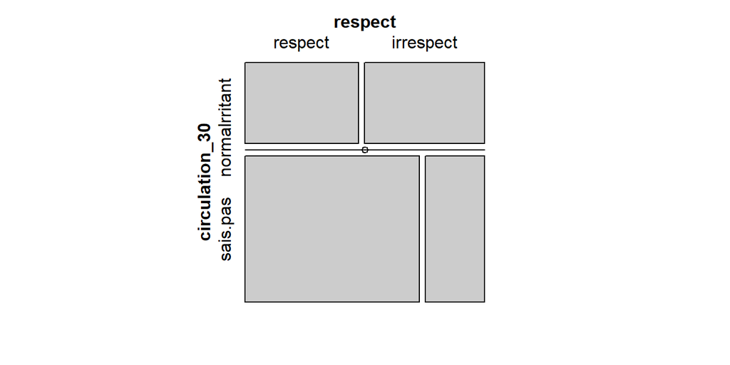

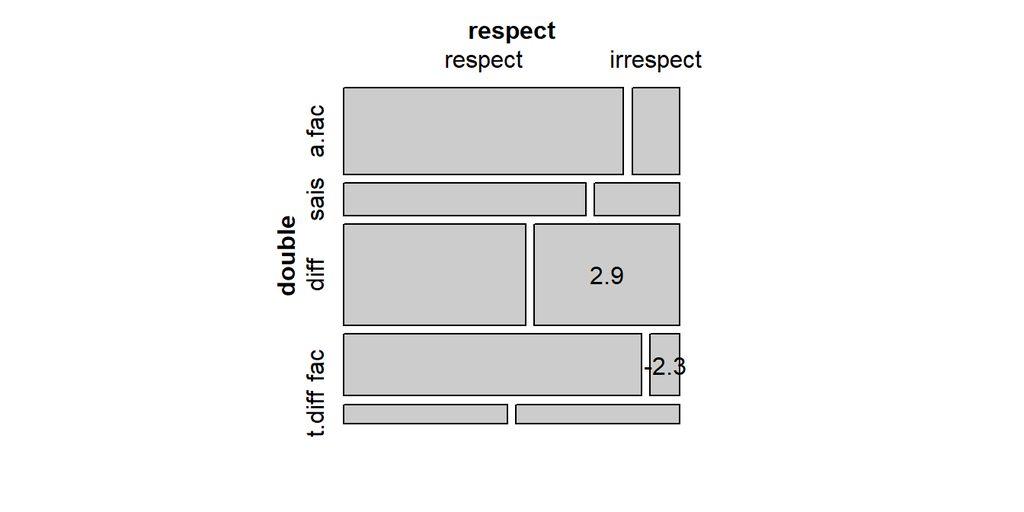

Plus de la moitié des automobilistes considèrent que le fait que les cyclistes n’empruntent pas les aménagements cyclables est anormal ou irritant. Le sentiment d’irritation provoqué par ce fait est significativement lié au sentiment que les cyclistes sont irrespectueux. Par contre, les automobilistes qui trouvent ce fait normal, trouve les cyclistes respecteux et ce, de manière significative.

De la même manière, les automobilistes qui trouvent le fait que des cyclistes se mettent au niveau des SAS vélo irritant, trouvent le comportement des cyclistes irrespectueux et ce de manière significative. Toutefois, une majorité des automobiblistes trouvent ce fait normal.

Pour ce qui est du sentiment suscité par la circulation en zone 30, il n’a aucun impact sur le sentiment des automobilistes d’être manqués de respect par les cyclistes. Le désagrément causé par la ciculation en ces zone est donc négligeable.

Pour ce qui est des doubles-sens cyclable, le sentiment que le partage de ces axes avec les cyclistes est difficile est significativement au sentiment des automobilistes que les cyclistes ne sont pas respectueux, contrairement aux automobilistes qui considèrent ce partage comme étant “facile”.

Ainsi, l’amélioration du vivre-ensemble entre automobilistes et cyclistes nécessite de sensibiliser davantage les automobilistes sur les SAS vélo, les doubles-sens et la non obligation pour les cyclistes d’emprunter les aménagements cyclables.

## b- Connaissances du code de la route

La sensibilsation sur d’autres aspects du code de la route peut être aussi cruciale, notamment les doubles-sens cyclables, les panneaux tourne-à-droite et les zone 30.

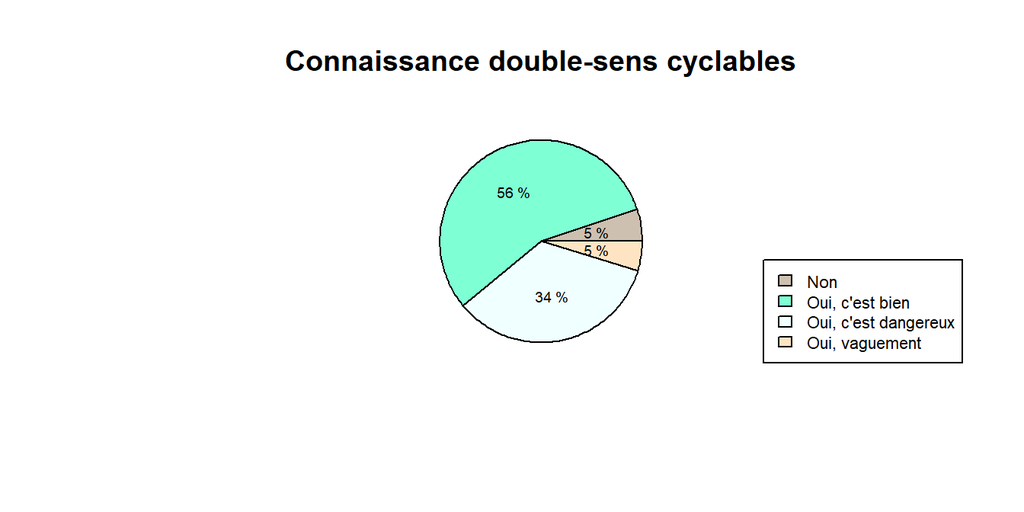

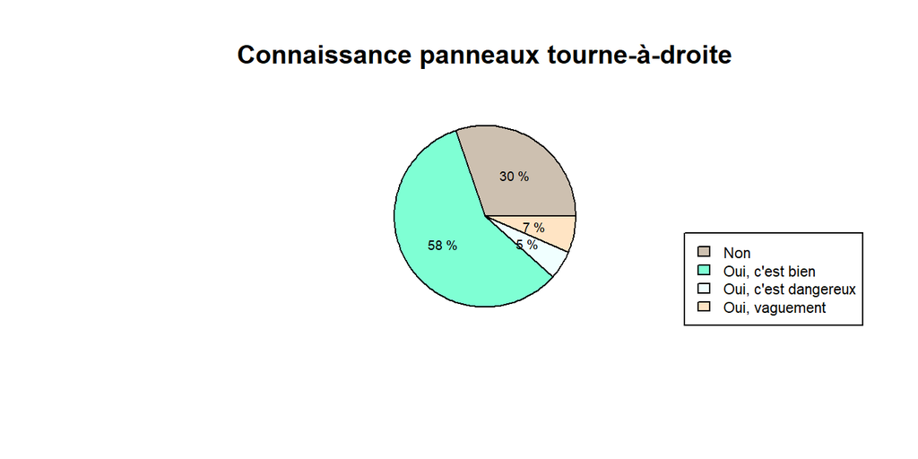

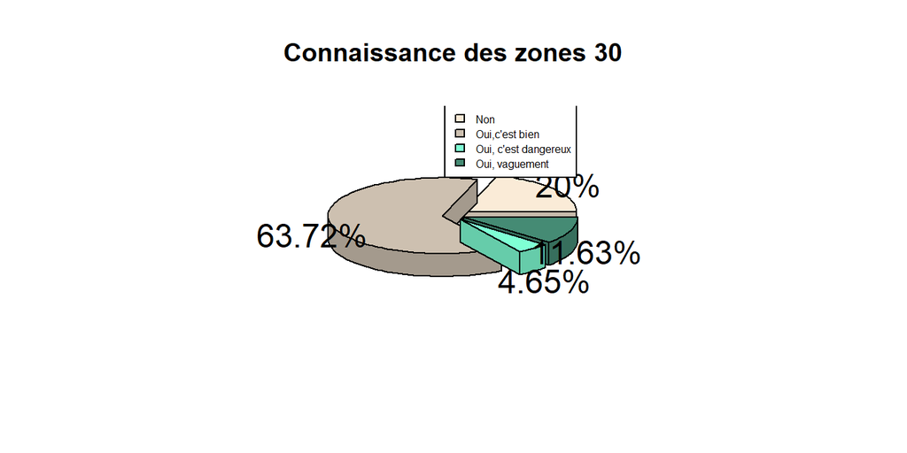

Comme le respect entre les usagers, la connaissance de ces éléments du code la route touchant les cyclistes, contribue à éviter les conflits entre les usagers ou la mise en danger des usagers vulnérables, en l’occurrence les cyclistes.

Les causes de conflits les plus fréquentes entre cyclistes et automobilistes sont celles causées par le frôlement d’un cycliste par un automobiliste (27%) ou un cycliste qui brûle un feu rouge (20%). De plus, une faible proportion d’automobilistes affirme avoir eu un conflit avec un cycliste, soit 28%, et les différentes causes se répartisssent comme dans la figure suivante:

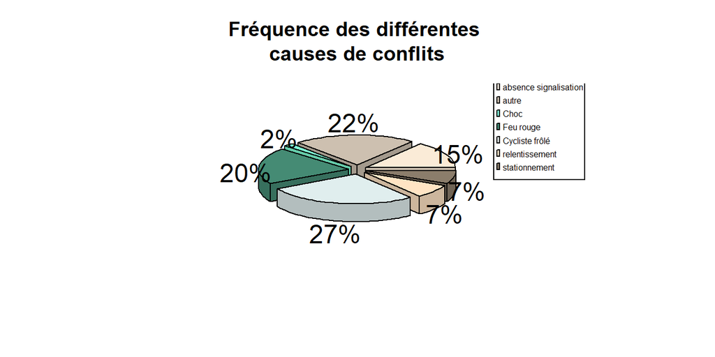

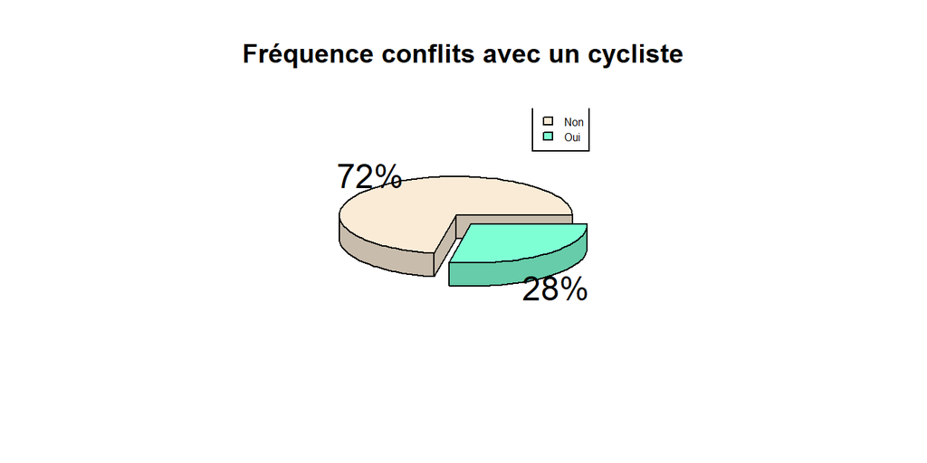

Les éléments considérés afin d’expliquer la fréquence des conflits entre automobilistes et cyclistes sont: si l’automobiliste a déjà entendu parler des panneaux tourne-à-droite, des doubles-sens cyclables, ou des zones trente. Cependant, le lien entre la connaissance de ces éléments et le fait d’avoir un conflit avec un cycliste est inexistent ou n’est pas significatif.

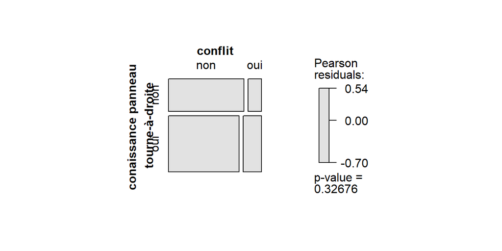

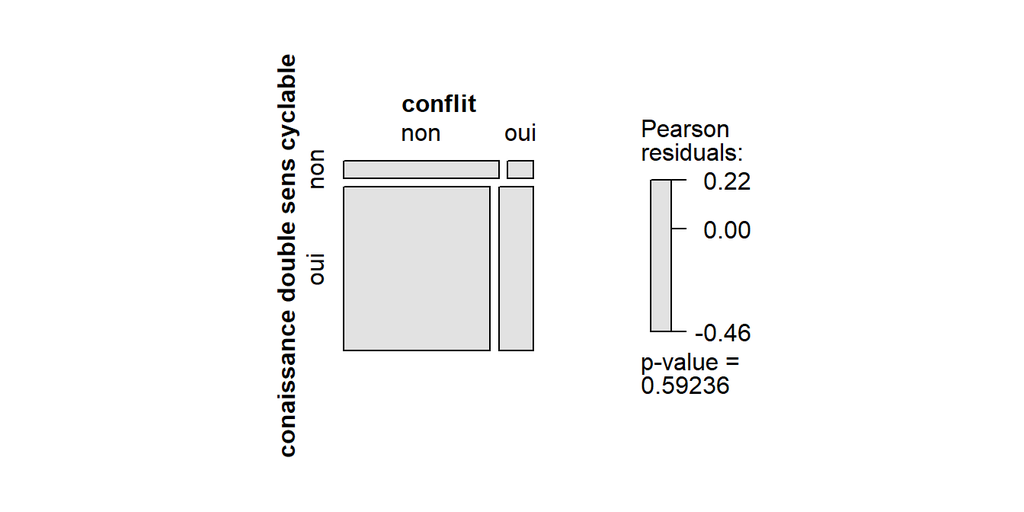

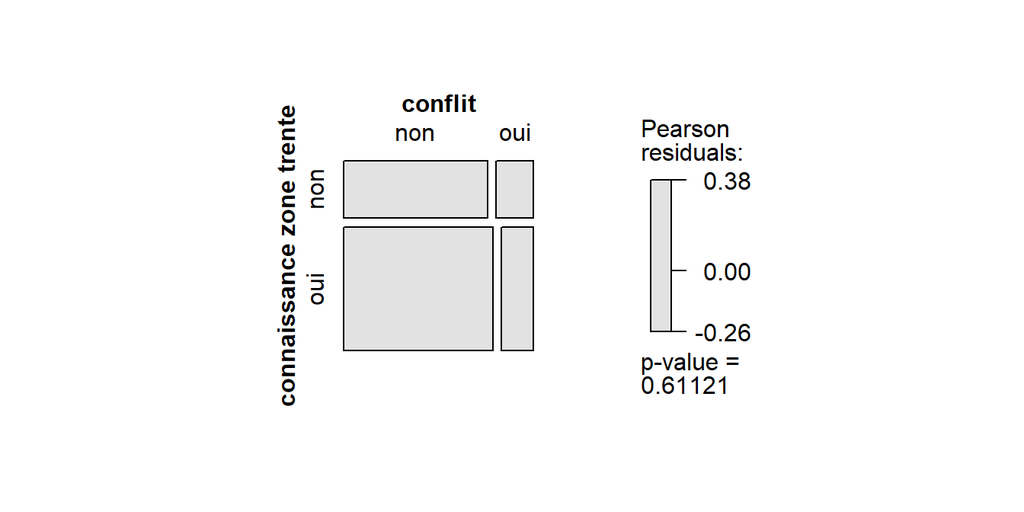

Ce résultat est confirmé par la visualisation des rapports de côte dans la figure suivante où la probabilité de conflit reste la même quelque soit la condition.

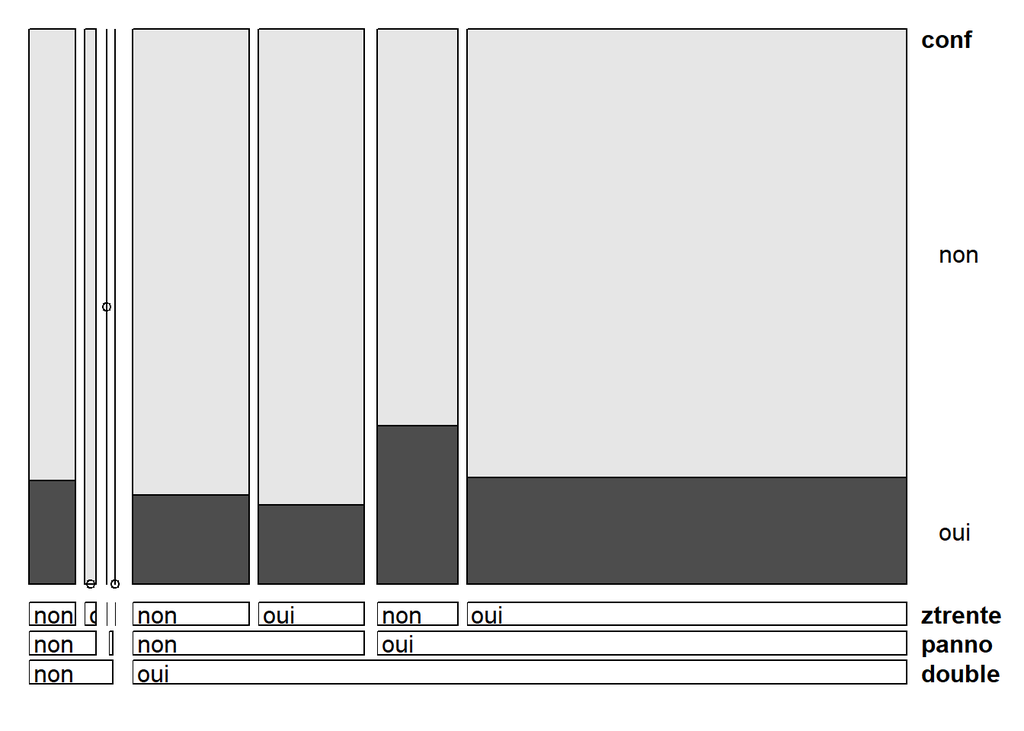

En outre, l’avènement d’un conflit n’affecte pas significativement la satisfaction des automobilistes concernant leur partage de la chaussée avec les cyclistes. Le test d’associativité (calculant le coefficient de contingence et le V de Cramer) suivant indique qu’en effet, la satisfaction d’un automobiliste est indépendante de ses conflits avec un cycliste.

```
##                     X^2 df P(> X^2)
## Likelihood Ratio 2.2875  2  0.31862
## Pearson          2.3240  2  0.31285
##
## Phi-Coefficient   : NA
## Contingency Coeff.: 0.103
## Cramer's V        : 0.104
```

Ainsi, le sentiment de manque de respect est la principale source d’insatisfaction des automobilistes. Ce manque de respect se traduit par le relentissement en ciculation, la non utilisation des aménagements cyclables et le fait de se mettre au niveau des SAS vélo aux feux rouges.

## c- Analyse des commentaires des automobilistes

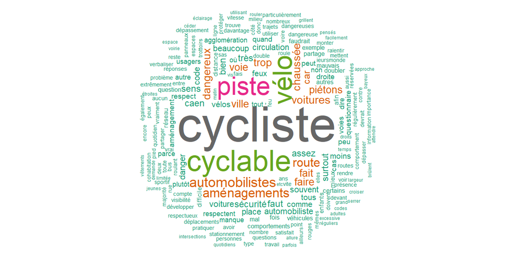

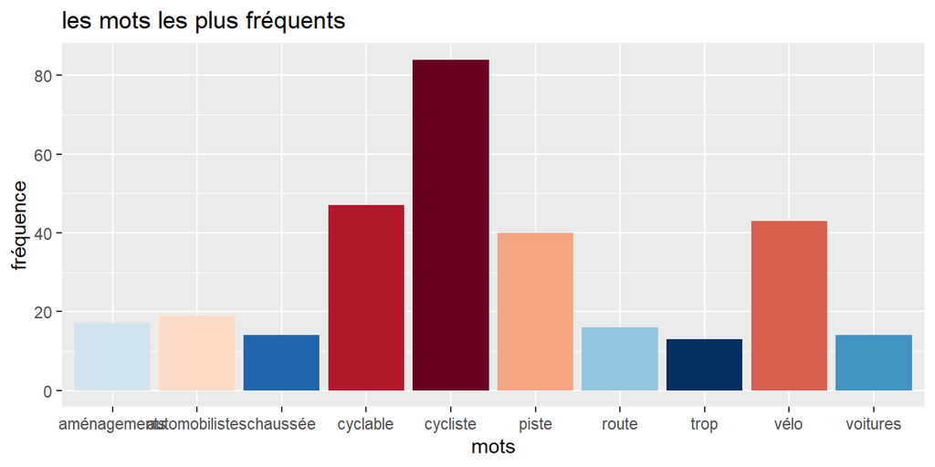

Les commentaires des automobilistes portent essentiellement sur la question du vivre ensemble et les facteurs qui empêchent ce dernier, notamment le comportement des cyclistes. Sur ce point, il est mis en exergue l’indiscipline des cyclistes qui se traduit par:

- un non respect du code de la route avec surtout, un non respect des feux rouges;
- le fait que les cyclistes n’empruntent pas les aménagement qui leur sont dédiés et ainsi ralentissent la circulation;
- le fait que les cyclistes empruntent les trottoirs, ce qui est vu comme un manque de respect envers les piétons.

```r
"[1] les cycliste qui empruntent les trottoirs, c'est pas bien"

"[20] verbaliser les cycliste qui brûlent les feux rouges"

"...l'utilisation des doubles-sens, tourne à droite, etc. peut bien se passer si il y a
respect du code de la route, et des signalétiques : un cycliste qui roule au milieu de
la voie dans un double sens est dangereux et irritant parce que ralentissant le véhicule venant
en face..."
```

Outre le comportement des cyclistes, les commentaires ont porté aussi sur les pistes cyclables ainsi que le comportements des automobilistes, notamment:

- le nombre insuffisant d’aménagement cyclables rendant la cohabitation difficile,
- l’inadaptabilité de ces aménagements en particulier l’étroitesse, l’entretien et la discontinuité.
- les automobibilistes qui mettent les cyclistes en danger par une vitesse élevée et un doublement qui ne respecte pas la distance de sécurité.

# Conclusion

Au terme de cette analyse, il ressort que le sentiment d’insécurité routière est très présent chez les cyclistes et ce, de manière absolue. Autrement dit, le cycliste ne sent pas en sécurité dans la circulation quelque soit son âge, sa zone de résidence ou son sexe. Ce sentiment d’insécurité est significativement lié à son exposition au niveau des ronds-points, les intersections et les routes départementales. Ainsi, dans l’optique d’améliorer la sécurité des cyclistes et d’encourager l’usage du vélo, nos suggestions afin d’atteindre cet objectif sont:

- mettre des pistes cyclables ou des marquages ou signalisation en faveur des cyclistes au niveau des ronds-points et intersections;
- au niveau des routes départementales, étant donné que la vitesse des véhicules est la source d’insécurité des cyclistes, construire des pistes cyclables avec une séparation physique avec la chaussée;

Pour les automobilistes, leur insatisfaction de leur partage de la chaussée avec les cyclistes ainsi que leur sentiment que ces derniers sont irrespectueux découlent significativement de:

- les cyclistes les relentissent dans la circulation ou se mettent au niveau des SAS vélo aux feux rouges;
- le partage des doubles-sens cyclables est difficile et irritant;
- les cyclistes n’empruntent pas les pistes cyclables lorsqu’elles en existent.

Ainsi, une amélioration du vivre ensemble entre automobilistes et cyclistes doit nécessairement passer par une sensibilisation sur ces différents aspects. En d’autres termes, il s’agit de:

- sensibiliser les automobilistes sur le fait les cyclistes ont le droit de se mettre au niveau des SAS vélo devant eux au niveau des feux rouges. Aussi les sensibiliser sur le fait que les aménagements cyclables peuvent ne pas être adaptés. Dans ce cas, les cyclistes ont le droit de ne pas les emprunter. La connaissance de ce droit pourra permettre d’éviter d’éventuels conflits verbaux.
- informer et former les automobilistes sur l’existence de doubles-sens et comment les partager avec les cyclistes.
- d’un point de vue personnel, former les automobilistes, cylistes et piétons à l’esprit de partage de la chaussée et et le respect es autres usagers. D’où l’important de l’initiation à la pratique du vélo dès le bas âge.

Ainsi, cette étude a permis d’établir des mesures relativement précises. En effet, la constitution d’un échantillon représentatif permet une estimations des proportions avec des taux d’erreur inférieurs à 3% pour les cyclistes et 5% pour les automobilistes.

# Annexe

### Le questionnaire qualitatif

Le questionnaire qualitatif a pour objectif d’explorer en amont la question de la sécurité routière et de la perception réciproque entre les usagers de la route au niveau du Calvados. Ce questionnaire supplée au focus groupe. Ainsi, son objectif est de recenser les points qui interpellent les usagers par rapport à leur sécurité sur la route. Le questionnaire est composé de 10 questions portant sur les aménagements et les comportements potentiellement dangereux lors d’interactions vélos/voitures. Cette analyse porte sur 183 réponses recueillies en ligne. Ci-après les 10 questions du questionnaire:

- Question 1 : Vous sentez-vous en sécurité sur les aménagements cyclables que vous empruntez ?
- Question 2: En tant que cycliste, quels sont les aménagements routiers sur lesquels vous ne vous sentez pas en sécurité (intersection, rond-point, type de voies…) ?
- Question 3 : Sur ces endroits sensibles en termes de sécurité quels sont les comportements dangereux que vous avez pu identifier ?
- Question 4 : Pour vous, quelles sont les manœuvres des autres usagers qui vous mettent en danger dans la circulation ou vous font peur ?
- Question 5 : Lorsque vous circulez en vélo, avez-vous déjà entendu des remarques désobligeantes du type « moi je travaille… » ? Quelles sont ces remarques et dans quel contexte cela s’est-il produit ?
- Question 6: Si oui, dans votre cas, quels sont souvent les facteurs déclencheurs de ces conflits ?
- Question 7 : En tant qu’usager d’un véhicule motorisé, vous arrive t’il qu’un cycliste vous fasse peur de par son comportement ?
- Question 8 : En tant qu’automobiliste, est ce qu’un cycliste vous a déjà fait des remarques désobligeantes ? Quelles sont ces remarques et dans quel contexte cela s’est-il produit ?
- Question 9 : En tant qu’automobiliste, quelles sont les évolutions récentes du code de la route dont vous êtes au courant concernant les cyclistes ?
- Question 10 : Veuillez laisser un commentaire (ou suggestions) sur la sécurité routière et le vivre ensemble (voiture / vélo) dans la circulation ?

### Question 1 : Vous sentez-vous en sécurité sur les aménagements cyclables que vous empruntez ?

Le nuage de mots associé est le suivant:

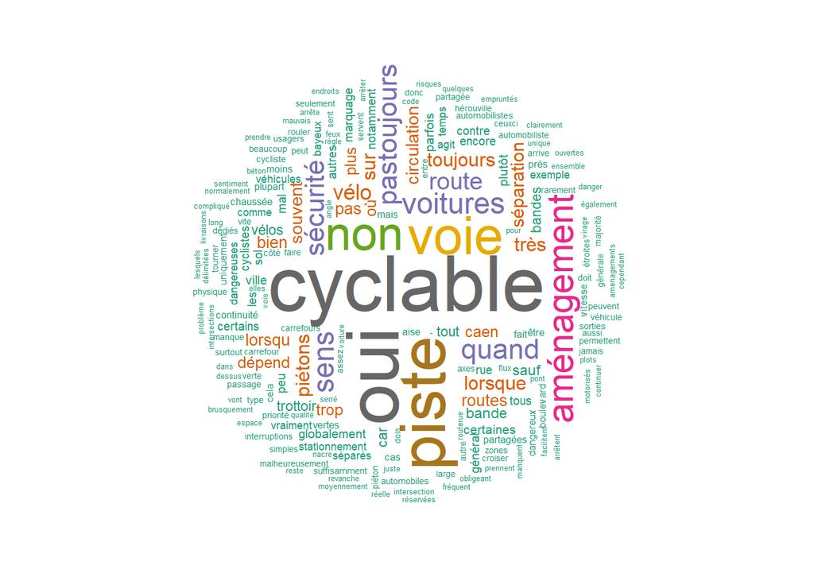

Ainsi, les mots les plus fréquents sont les suivants: “oui”, “non”, “pas toujours”, “quand”, “voie”, “piste”, “cyclable,”séparation“,”voitures" et “piétons”

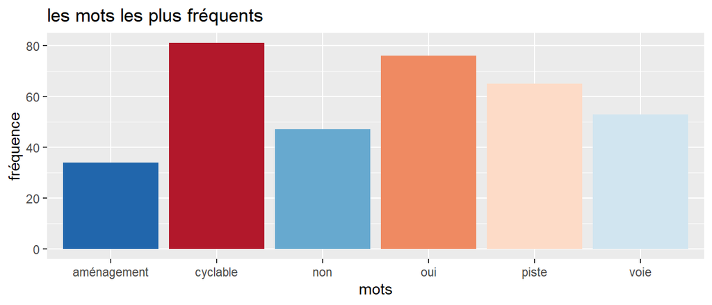

```r
"[1] cela dépend des aménagements lorsqu'il sagit d'une voie
réservée séparée de la route  oui. Lorsquil sagit dun marquage
type voie partagée sur de petites routes  oui. Lorsqu'il sagit
d'un marquage type voie partagée sur des axes importants
boulevard non.

[3] lorsque je roule sur une voie cyclable dédiée oui.Lorsqu'il
s'agit d'une voie partagée clairement non. Certains individus
semblent prendre un malin plaisir à frôler les cyclistes je ne me
sens pas suffisamment en sécurité sur ces voies là.

[4] oui et non. Lorsquils sont séparés par une barrière physique
et que la voirie est en bon état, oui. Lorsque ce sont de simples
bandes cyclables sans séparation, non"
```

Ainsi, nous constatons que les cyclistes ne se sentent pas en sécurité sur les aménagements cyclables quand:

- il n’existe pas une séparation physique entre la voie cyclable et la chaussée. En particulier, au niveau des grands axes tels que les boulevards où les flux et la vitesse autorisée sont assez élevés. Même si certains cyclistes se sentent en sécurité sur les voies partagées par marquage sur les petites routes, d’autres ne s’y sentent pas en sécurité. Le sentiment d’insécurité quand la route est partagée vient du frôlement des automobilistes.
- l’aménagement en question est discontinu;
- des véhicules sont stationnés sur l’aménagement, les obligeant ainsi à déboîter sur la chaussée;
- l’aménagement n’est pas en bon état ou est étroit.

Par ailleurs, les voies vertes restent des aménagements sûrs presque à l’unanimité.

Nous allons nous intéresser aux questions 2 et 3:

### Question 2: En tant que cycliste, quels sont les aménagements routiers sur lesquels vous ne vous sentez pas en sécurité (intersection, rond-point, type de voies…) ?

### Question 3 : Sur ces endroits sensibles en termes de sécurité quels sont les comportements dangereux que vous avez pu identifier ?

Le nuage de mots associé est le suivant:

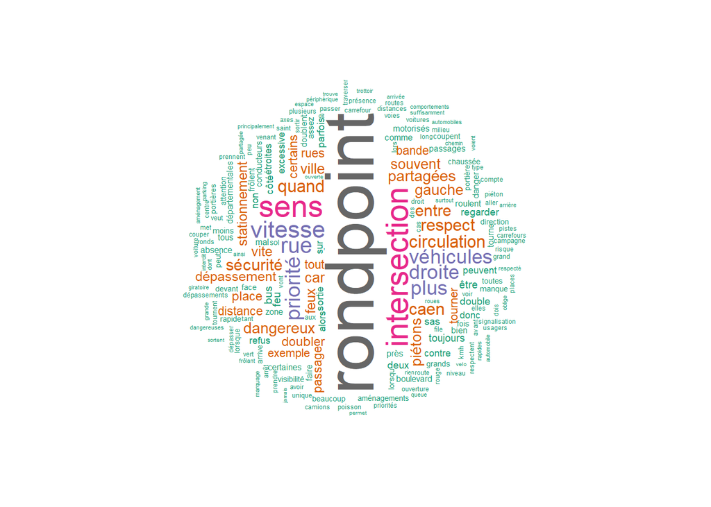

Les termes les plus fréquents sont: “rond-point”, “intersection”, “vitesse”, “priorité” et “droite”:

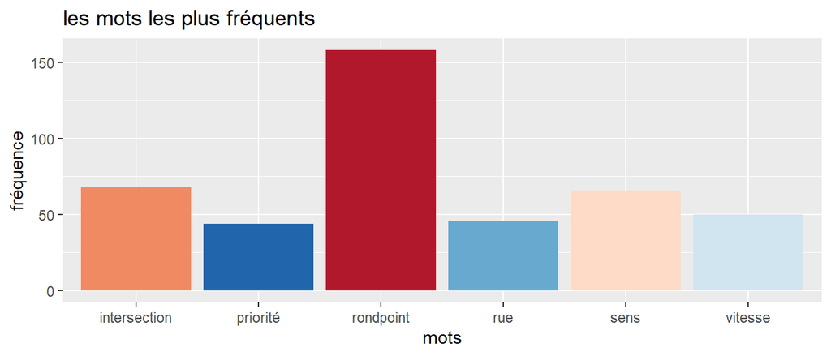

```r
"[1] Certaines intersections et presque tous les rondpoint point.
La vitesse des voitures.

[2] Dès lors qu’une voie cycliste n’est pas physiquement séparée
de la route, ne serait-ce que par des bornes visibles. Évidement
sur les rondpoint-points et les intersections. Les automobilistes
sont peu prudents voire même dangereusement provocateurs, avec
l’idée de défendre leur territoire.Des voitures qui se rabattent
sans faire attention, qui ne respectent pas les priorités
cyclistes, qui ne laisse quasiment pas d’espaces entre eux et le
vélo.

[21] intersection et rondpoint-point refus de priorité."
```

Les aménagements sensibles les plus cités sont: les rond-ponts, les intersections. Le sentiment d’insécurité au niveau de ces aménagements provient:

- de la vitesse des voitures;
- du refus de priorité pour les cyclistes;
- du manque d’attention ou de considération: accélérations intempestives à l’approche des cyclistes;
- du non respect de la distance de sécurité;
- au niveau des ronds-points, et intersections où des véhicules qui tournent à droite bloquent le passage aux cyclistes.

### Question 4 : Pour vous, quelles sont les manœuvres des autres usagers qui vous mettent en danger dans la circulation ou vous font peur ?

Le nuage de mots des différentes réponses est le suivant:

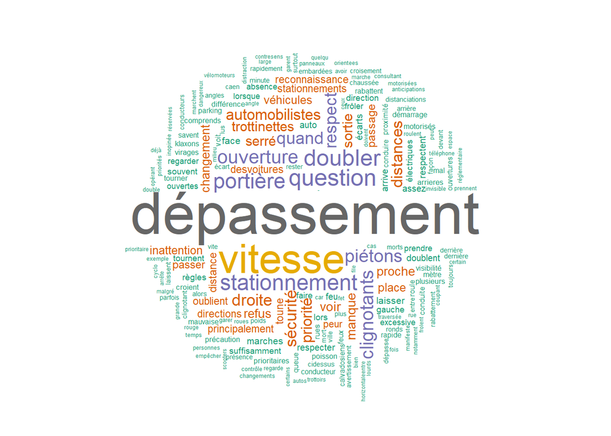

Les termes les plus fréquents sont donnés par la figure suivante: “vitesse”, “dépassement”, “doubler”, “stationnement”,“ouverture”, “portière”, et “droite”.

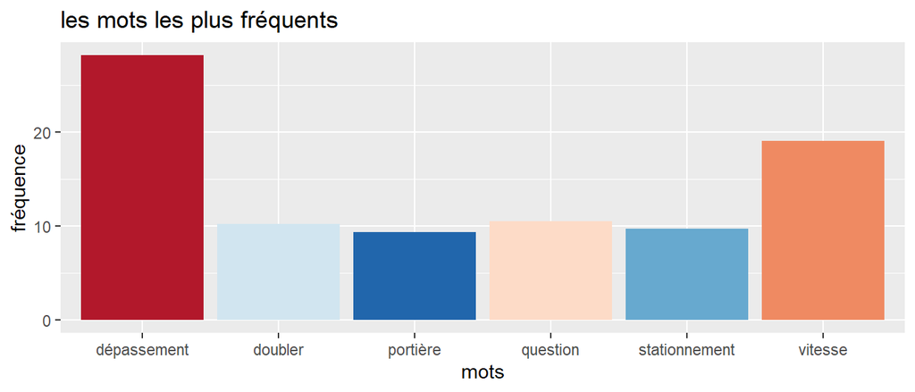

```r
"[1] Ecartement insuffisant des automobilistes lors d'un
dépassement.mauvaise appréciation de la vitesse des
cyclistes qui entraîne deux types de situations dangereuses :
- au croisement, l'automobiliste grille la priorité au cycliste
lorsque celui-ci est prioritaire.
- la manœuvre de dépassement de l'automobiliste est plus longue que
prévue ce qui l'amène parfois à abréger sa manœuvre de manière
hasardeuse, généralement en 'queue de poisson' pour le cycliste.les edp
sont des usagers nouveaux sur la voirie et leurs
comportements ou habitudes de circulation encore méconnus. difficile
d'anticiper leur comportement ce qui complexifie les manœuvres de
dépassement ou autre).

[2] les piétons sur les pistes,  les stationnements des voitures."
```

Les manoeuvres et comportements jugés dangereux sont:

- les manoeuvres de dépassement: distance non respectée;
- les “queue de poisson”;
- les stationnements qui rétrécissent davantage l’espace cyclable;
- les déplacements imprévisibles des piétons sur les pistes cyclables.

### Question 5 : Lorsque vous circulez en vélo, avez-vous déjà entendu des remarques désobligeantes du type « moi je travaille… » ? Quelles sont ces remarques et dans quel contexte cela s’est-il produit ?

### Question 6: Si oui, dans votre cas, quels sont souvent les facteurs déclencheurs de ces conflits ?

Le nuange de mots des réponses aux questions 5 et 6 est le suivant:

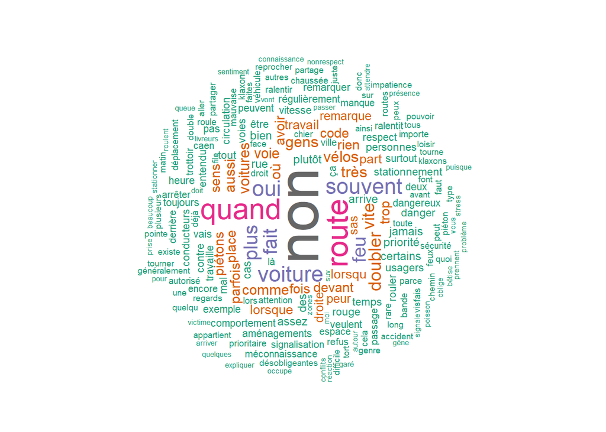

Les mots les plus fréquents sont les suivants: “non”, “quand”, “route”, “voiture” et “doubler”.

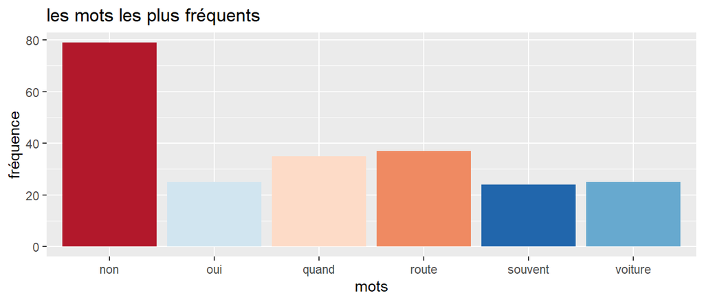

Les réponses par “non” l’emportent largement sur les “oui”. Toutefois, les comportements désobligeants ne se traduisent pas toujours par des remarques verbales mais par des regards, klaxons ou des “doigt d’honneur”. Ci-après deux exemples d’extraits illustratifs:

```r
"[3] non, pas trop de remarques désobligeantes... oui, j'ai déjà
'senti' des remarques, regards, ou gestes désobligeants....mais
je comprends...
[4] Non Des remarques désobligeantes : non. Une totale
indifférence aux problèmes de certains : oui ! Hélas."
```

Par ailleurs, ceratines remarques permettent d’avoir une idée sur la perception des automobilistes envers les cyclistes:

```r
"vous ne voyez pas que vous faites chier tout le monde ?

  je travaille, circulez.

Et la piste cyclable, c'est pas pour les chiens.

tu n’avais rien à faire sur la route."
```

Ces remarques traduisent le fait que:

- certains automobilistes perçoivent le vélo comme un outil de loisir;
- certains automobilistes refusent de partager la chaussée avec les cyclistes et ignorent le fait que les cyclistes ne sont pas obligés d’emprunter les aménagements cyclables dans certains cas.  
  Ainsi, ces conflits verbaux interviennent dans les contextes suivants:
- quand les automobilistes ne peuvent pas doubler;
- quand la présence d’un cycliste les surprennent dans la circulation et au niveau des contre-sens cyclables;
- quand le cycliste est frôlé;
- quand une voiture tournant à droite refuse la priorité à un cycliste;
- quand un automobiliste stationne sur les aménagements cyclables;
- quand les cyclistes se placent dans les SAS vélo devant les automobilistes au feu rouge;
- quand le cycliste ne s’arrête pas au feu rouge alors que, dans certains cas, le panneau tourne-à-droite cycliste l’y autorise.

```r
"[1] Quand les voitures ne peuvent pas doubler.Ou quand les automobilistes sont 'jaloux'
qu'on aille plus vite qu'eux (embouteillages ou tourne à droite).

[2] quand les conducteurs ou piétons ont été surpris de ma présence.
La première réaction est l'attaque alors que je suistoujours dans mon droit.

[3] quand je rale parce que j'ai été frôlee par une voiture.
Que je traverse et que mon feu est vert et le leur des voitures
tournant a droite aussi.

[4] En résumant ce que j’ai régulièrement entendu (environ une
dizaine de fois en 3 ans) c’est souvent autour de « vous nous
faites chier les cyclistes ». Sinon l’attaque habituelle sur le
prétendu non respect des règles par les cyclistes, surtout quand
on les prend en défaut sur ces règles. Les priorités, le non
respect des sas vélo et des pistes cyclables (notamment pour les
stationnement sur pistes)."
```

### Question 7 : En tant qu’usager d’un véhicule motorisé, vous arrive t’il qu’un cycliste vous fasse peur de par son comportement ?

Le nuage de mots associé est le suivant:

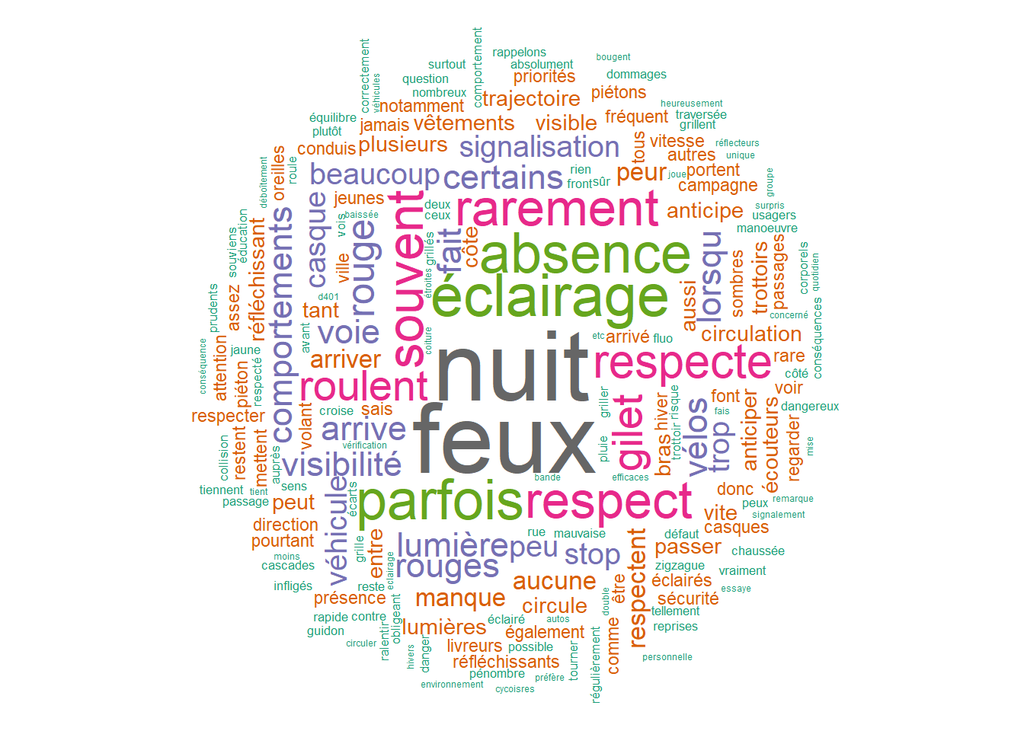

Ainsi, les mots les plus fréquents sont: “nuit”, “absence”, “éclairage”, “casque”, “visibilité”, “gilet”, “respect”, “feux”, “rouge”.

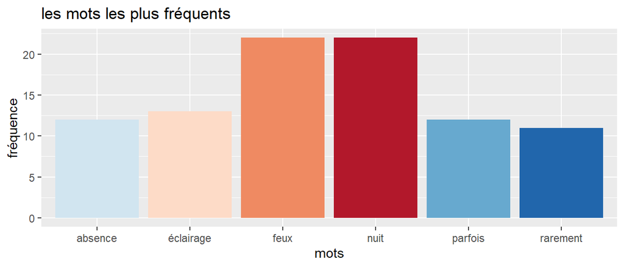

```r
"[6] Oui. Les cyclistes ne sont pas forcément vertueux. Le
problème le plus fréquent c’est un défaut de visibilité la nuit.
La D401 n’est pas éclairé la nuit et l’hiver il m’est arrivé à
plusieurs reprises d’être « surpris » (freinage brusque) par des
cyclistes non éclairés, sans gilet réfléchissant, sans
catadioptres, habillés en sombre. Je me souviens de l’un d’eux
qui était en survêtement noir mat en décembre à 18h30.

[3] oui par absence de feux , absence de gilet jaune , absence de
casque , cascades sur la route , absence de bras tendu pour
indiquer le changement de direction.

[10] Oui, quand il ne respecte pas les feux."
```

Les comportements dangereux des cyclistes se résument à:

- l’absence d’éclairage en particulier la nuit;
- le non respect des feux rouges;
- déboîtement intempestif.

### Question 8 : En tant qu’automobiliste, est ce qu’un cycliste vous a déjà fait des remarques désobligeantes ? Quelles sont ces remarques et dans quel contexte cela s’est-il produit ?

Le nuage de mots associés est le suivant:

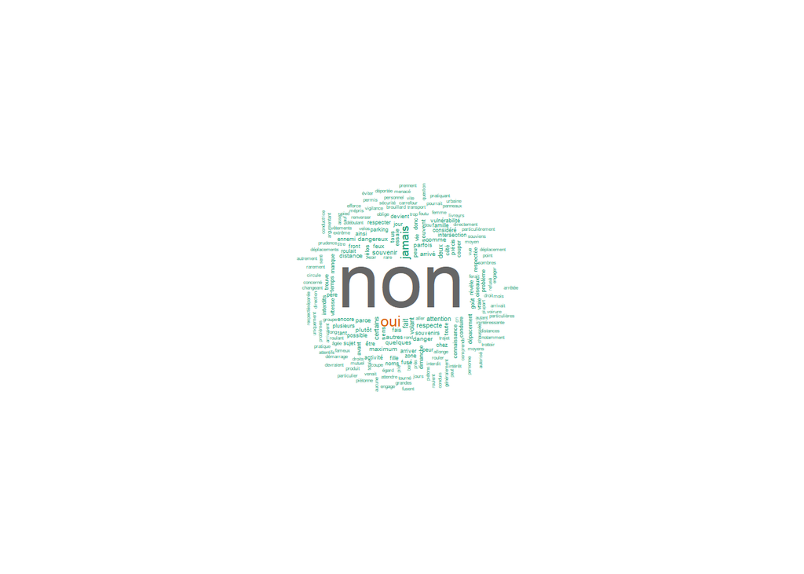

Les termes les plus fréquents sont: “non”, “jamais”, “oui”.

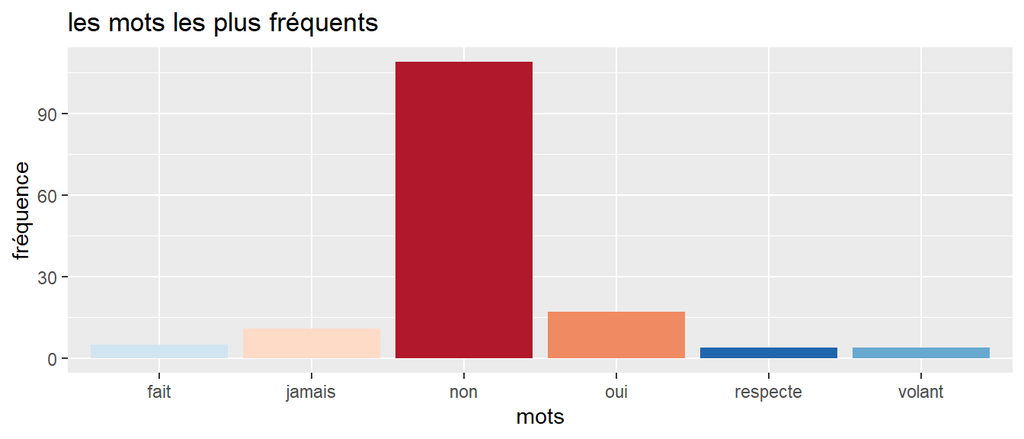

```r
"[10] Des remarques désobligeantes : non. Une totale
indifférence aux problèmes de certains : oui ! Hélas

[4] oui. Des cyclistes sportifs qui arrivaient à toute vitesse
que je n'avais pas vu."
```

### Question 9 : En tant qu’automobiliste, quelles sont les évolutions récentes du code de la route dont vous êtes au courant concernant les cyclistes ?

Le nuage de mots associé est le suivant:

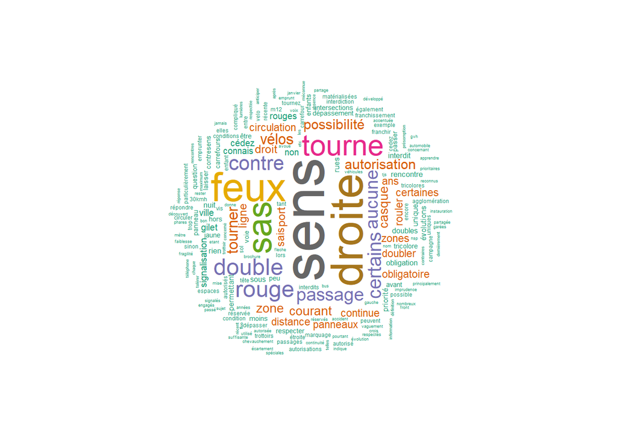

Les mots les plus fréquents sont: “double”, “sens”, “tourne”, “tourner”, “droite”, “feux”, “rouge”, “sas”.

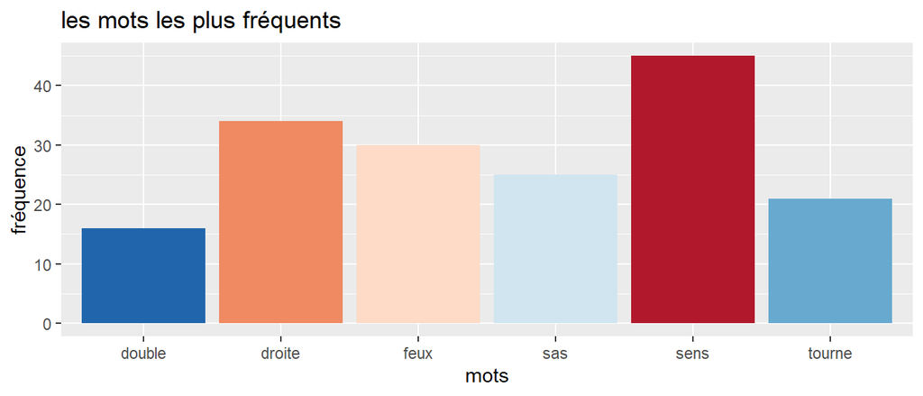

```r
"[19] Port du casque obligatoire pour les - de 12 ans.
Possibilité pour un enfant de rouler sur le trottoir (jusqu'à 8
ans). 'Gilet jaune' hors agglo, la nuit ... Double-sens cyclable,
'laisser le passage aux feux', priorité en zone 30 et zone de
rencontre. Franchissement de ligne continue autorisée pour
l'automobiliste qui double un cycliste.

[20] Sas velo, tourne à droite, contresens
[21] Les sens uniques interdits aux voitures mais permis aux
cyclistes.\nLes possibilités de tourner à droite aux feux rouges.
[22] Je suis au courant pour le tourne à droite à certains feux,
le double sens de certaines rues en sens interdit, les sas vélos
aux feux.
```

Ainsi, les nouveautés du code les plus citées sont:

- les doubles sens cyclables;
- le tourne-à-droite au feu triocolore;
- les sas vélo au feu.

### Question 10 : Veuillez laisser un commentaire (ou suggestions) sur la sécurité routière et le vivre ensemble (voiture / vélo) dans la circulation ?

Le nuage de mots associé est le suivant:

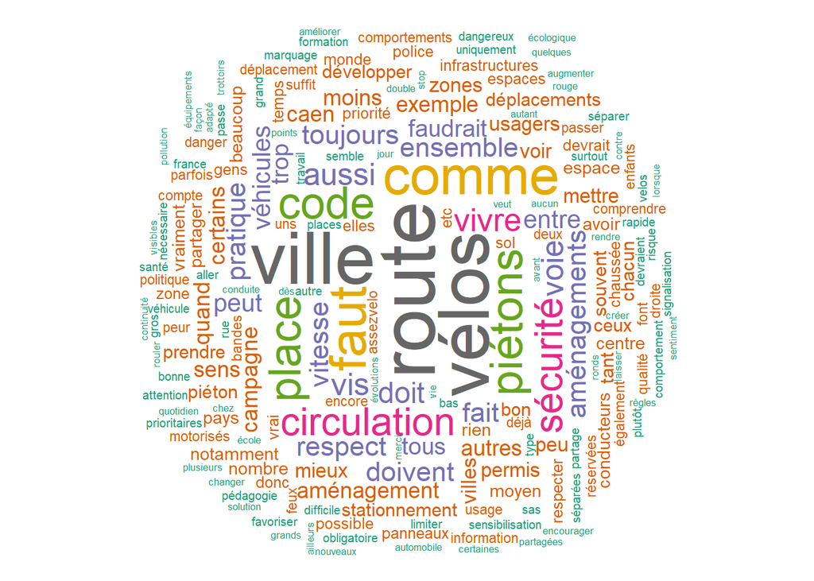

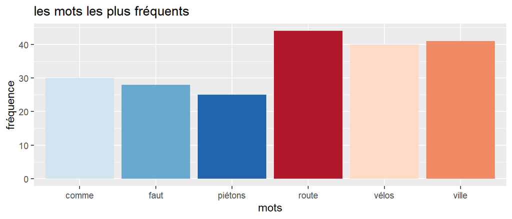

L’analsye des extraits associés aux termes les plus fréquents notamment “ville”, “vélos”, “sécurité”, “circulation”, “vivre”, “ensemble” “route”, permet de déceler que les différents thèmes abordés sont:

- le sentiment d’insécurité des cyclistes;
- l’ignorance des nouveauté du code de la route, en particulier en ce qui concerne les vélos;
- les stationnements sur les aménagements cyclables;
- la qualité des aménagements cyclables;
- le fait que le vélo soit considéré comme un outils de loisir;
- les sentiments que les automobilistes refusent de partager la chaussée

Ainsi, certaines suggestions ont été faites telles que:

- porter à la connaissance des automobilistes les nouveautés du code de la route;
- la limitation de la vitesse en ville;
- la généralisation des zone 30;
- donner toujours la priorité aux plus vulnérables (les piétons puis les cyclistes);
- verbalisation des mauvaises habitudes (refus de priorité au cycliste, stationnement sur des aménagements cyclables);
- la séparation entre les aménagements cyclables et la chausée (en particulier au niveau des routes de campagne et les axes où la vitesse autorisées est élevé);
- la sensibilisation des usagers (automobilistes et piétons) au vivre ensemble.

```r
"[1] - développer les messages pédagogiques vis à vis de la pratique
du vélo à destination des automobilistes
- développer une culture vélo
- réduire la vitesse en ville
- faire comprendre aux automobilistes qu'ils ne sont pas seuls sur la chaussée.

[2] la séparation entre les aménagements cyclables et la chausée (en particulier
au niveau des routes de campagne et les axes où la vitesse autorisées est élevé).

[3] généralisation du 30 km/h en ville, sauf les grands axes
structurants qui pourraient rester à 50km/h.

[5] Tout dépend de la volonté politique des maires à diminuer la
place excessive prise par la voiture en ville... Beaucoup de
communes envisagent le développement du vélo et la marche à pied
mais sans que les aménagements ne prennent 1 cm2 à la voiture...
Les communes doivent être plus offensives : généraliser zones 30
dans les hypercentres ouvertes au double sens cyclable, maîtrise
du stationnement, lutte contre le stationnement sauvage et
illicite (tant Police Municipale que Police ou Gendarmerie
Nationale), restreindre la place pour les SUV (ex 4x4) qui se
développement conter toute logique... Les vieux schémas sur la
voiture reine en ville ont la vie dure, notamment en Normandie.""
```

### Conclusion:

A partir de ces résulats, un questionnaire quantitatif sera élaboré. L’objectif étant, à partir d’un échantillon représentatif du Calvados, de quantifier ces différentes réponses relatives à la sécurité routière et à la perception réciproque entre les usagers de la route.

# Bibliographie

http://www.adjectif.net/spip/spip.php?article58

http://www.caen-metropole.fr/content/enquete-menages-deplacements

https://www.calvados.fr/accueil/le-departement/routes-environnement--territoire/se-deplacer-autrement/plan-velo.html

https://www.data.gouv.fr/fr/datasets/enquete-deplacements-villes-moyennes-edvm-1/

https://www.ecologique-solidaire.gouv.fr/plan-velo-et-mobilites-actives

https://www.ecologique-solidaire.gouv.fr/velo-et-marche

https://edgt.hautesavoie.fr/bibliotheque-de-documents

https://www.francemobilites.fr/

https://www.fub.fr/velo-ville/securite-routiere/accidents-velo#_edn1

https://www.gouvernement.fr/sites/default/files/document/document/2018/09/dossier_de_presse_-_plan_velo_-_vendredi_14_septembre_2018.pdf

https://www.hauts-de-france.developpement-durable.gouv.fr/?Enquetes-de-circulation-routiere-principes-methodologiques

https://www.insee.fr/fr/statistiques/2011101?geo=DEP-14

https://www.insee.fr/fr/statistiques/2011101?geo=AU2010-022

https://www.insee.fr/fr/statistiques/1285202

https://www.insee.fr/fr/statistiques/1285202

http://www.progedo-adisp.fr/enquetes/XML/lil.php?lil=lil-0932#

http://pagesped.cahuntsic.ca/sc_sociales/psy/methosite/consignes/echantillon.htm

http://www.recherche-qualitative.qc.ca/documents/files/revue/edition_reguliere/numero28(1)/baribeau(28)1.pdf

https://fr.surveymonkey.com/mp/conducting-qualitative-research/

http://www.suristat.org/article269.html

http://www.smtc-clermont-agglo.fr/transports-en-commun-clermont/153_Les-objectifs-de-l-enquete.html

https://fr.wikipedia.org/wiki/Aire_urbaine_(France)